# ML - course Project

Marcelo M. Nobrega  
github:  
RPubs:

The goal of your project is to predict the manner in which they did the exercise. This is the “classe” variable in the training set. You may use any of the other variables to predict with. You should create a report describing how you built your model, how you used cross validation, what you think the expected out of sample error is, and why you made the choices you did. You will also use your prediction model to predict 20 different test cases.

## Background

Using devices such as Jawbone Up, Nike FuelBand, and Fitbit it is now possible to collect a large amount of data about personal activity relatively inexpensively. These type of devices are part of the quantified self movement - a group of enthusiasts who take measurements about themselves regularly to improve their health, to find patterns in their behavior, or because they are tech geeks. One thing that people regularly do is quantify how much of a particular activity they do, but they rarely quantify how well they do it. In this project, your goal will be to use data from accelerometers on the belt, forearm, arm, and dumbell of 6 participants. They were asked to perform barbell lifts correctly and incorrectly in 5 different ways. More information is available from the website here: http://groupware.les.inf.puc-rio.br/har (see the section on the Weight Lifting Exercise Dataset).

## Loading data and libraries

```r
# Data Sets
urltr <- "https://d396qusza40orc.cloudfront.net/predmachlearn/pml-training.csv"
urlte <- "https://d396qusza40orc.cloudfront.net/predmachlearn/pml-testing.csv"
if(!file.exists("./data")){
  dir.create("./data")
}
if(!file.exists("./train.csv")){
  download.file(urltr, destfile = "train.csv", method = "auto")
}
if(!file.exists("./test.csv")){
  download.file(urlte, destfile = "test.csv", method = "auto")
}
train <- read.csv("train.csv", header = T, stringsAsFactors = FALSE, na.strings = c("NA", ""))
test <- read.csv("test.csv", header = T, stringsAsFactors = FALSE, na.strings = c("NA", ""))
dim(train);dim(test)
```

```
## [1] 19622   160
```

```
## [1]  20 160
```

```r
colSums(is.na(train))
```

```
##                        X                user_name     raw_timestamp_part_1
##                        0                        0                        0
##     raw_timestamp_part_2           cvtd_timestamp               new_window
##                        0                        0                        0
##               num_window                roll_belt               pitch_belt
##                        0                        0                        0
##                 yaw_belt         total_accel_belt       kurtosis_roll_belt
##                        0                        0                    19216
##      kurtosis_picth_belt        kurtosis_yaw_belt       skewness_roll_belt
##                    19216                    19216                    19216
##     skewness_roll_belt.1        skewness_yaw_belt            max_roll_belt
##                    19216                    19216                    19216
##           max_picth_belt             max_yaw_belt            min_roll_belt
##                    19216                    19216                    19216
##           min_pitch_belt             min_yaw_belt      amplitude_roll_belt
##                    19216                    19216                    19216
##     amplitude_pitch_belt       amplitude_yaw_belt     var_total_accel_belt
##                    19216                    19216                    19216
##            avg_roll_belt         stddev_roll_belt            var_roll_belt
##                    19216                    19216                    19216
##           avg_pitch_belt        stddev_pitch_belt           var_pitch_belt
##                    19216                    19216                    19216
##             avg_yaw_belt          stddev_yaw_belt             var_yaw_belt
##                    19216                    19216                    19216
##             gyros_belt_x             gyros_belt_y             gyros_belt_z
##                        0                        0                        0
##             accel_belt_x             accel_belt_y             accel_belt_z
##                        0                        0                        0
##            magnet_belt_x            magnet_belt_y            magnet_belt_z
##                        0                        0                        0
##                 roll_arm                pitch_arm                  yaw_arm
##                        0                        0                        0
##          total_accel_arm            var_accel_arm             avg_roll_arm
##                        0                    19216                    19216
##          stddev_roll_arm             var_roll_arm            avg_pitch_arm
##                    19216                    19216                    19216
##         stddev_pitch_arm            var_pitch_arm              avg_yaw_arm
##                    19216                    19216                    19216
##           stddev_yaw_arm              var_yaw_arm              gyros_arm_x
##                    19216                    19216                        0
```

[output cut: 53 more lines]

```
##                    19216                        0                    19216
##         avg_roll_forearm      stddev_roll_forearm         var_roll_forearm
##                    19216                    19216                    19216
##        avg_pitch_forearm     stddev_pitch_forearm        var_pitch_forearm
##                    19216                    19216                    19216
##          avg_yaw_forearm       stddev_yaw_forearm          var_yaw_forearm
##                    19216                    19216                    19216
##          gyros_forearm_x          gyros_forearm_y          gyros_forearm_z
##                        0                        0                        0
##          accel_forearm_x          accel_forearm_y          accel_forearm_z
##                        0                        0                        0
##         magnet_forearm_x         magnet_forearm_y         magnet_forearm_z
##                        0                        0                        0
##                   classe
##                        0
```

Train data contains ~ 20k rows and 160 variables.  
Test data contains 20 rows and 160 variables. Several columns are basically NA values.  
I will remove columns with more than 70 % of NA an columns with near zero variance.

## Clean Data

```r
na_count <- function(y) mean(is.na(y)) <= 0.7
train <- train[sapply(train, na_count)]
test <-  test[sapply(test, na_count)]
# Missing values cleaned

NZVtr <- nearZeroVar(train, saveMetrics = TRUE)
NZVte <- nearZeroVar(test, saveMetrics = TRUE)
# Removing variables with NZV
train <- train[,NZVtr$nzv == FALSE]
test <- test[,NZVtr$nzv == FALSE]
```

Both Data sets ended up with 59 variables after cleaning them. Now I will split the train data set into two parts, training and testing, and I will remove the first 2 columns, that aren’t necessary and will not contribute to the model.

## Data spliting

```r
inTrain <- createDataPartition(train$classe, p = 0.7, list = FALSE)
training <- train[inTrain,-c(1:2)]
testing <- train[-inTrain, -c(1:2)]
```

## Modeling - Decision tree

Fitting a Decision tree and predicting in the testing set.

[figure not shown]

```r
set.seed(123)
tree <- rpart(classe ~., data = training, method = "class")
fancyRpartPlot(tree)
```

```r
predtree <- predict(tree, testing, type = "class")
confusionMatrix(predtree, testing$classe)
```

```
## Confusion Matrix and Statistics
##
##           Reference
## Prediction    A    B    C    D    E
##          A 1606   51    8    1    0
##          B   49  939   65   47    0
##          C   19  143  925  147   49
##          D    0    6   28  722  131
##          E    0    0    0   47  902
##
## Overall Statistics
##
##                Accuracy : 0.8656
##                  95% CI : (0.8566, 0.8742)
##     No Information Rate : 0.2845
##     P-Value [Acc > NIR] : < 2.2e-16
##
##                   Kappa : 0.8301
##  Mcnemar's Test P-Value : NA
##
## Statistics by Class:
##
##                      Class: A Class: B Class: C Class: D Class: E
## Sensitivity            0.9594   0.8244   0.9016   0.7490   0.8336
## Specificity            0.9858   0.9661   0.9263   0.9665   0.9902
## Pos Pred Value         0.9640   0.8536   0.7210   0.8140   0.9505
## Neg Pred Value         0.9839   0.9582   0.9781   0.9516   0.9635
## Prevalence             0.2845   0.1935   0.1743   0.1638   0.1839
## Detection Rate         0.2729   0.1596   0.1572   0.1227   0.1533
## Detection Prevalence   0.2831   0.1869   0.2180   0.1507   0.1613
## Balanced Accuracy      0.9726   0.8952   0.9139   0.8577   0.9119
```

As a first model it seems a good model with an accuracy of ~ 0.87.

## Predicting on Test Set

```r
predTe <- predict(tree, test, type = "class")
predTe
```

```
##  1  2  3  4  5  6  7  8  9 10 11 12 13 14 15 16 17 18 19 20
##  B  A  C  A  A  E  D  C  A  A  B  C  B  A  E  E  A  B  B  B
## Levels: A B C D E
```

## Modeling - Random Forest Model

```r
set.seed(124)
ctrRF <- trainControl(method = "cv", number = 2)
modelRF <- train(classe ~., data = training,
                 method = "rf",
                 ntree = 100,
                 trControl = ctrRF)
modelRF
```

```
## Random Forest
##
## 13737 samples
##    56 predictor
##     5 classes: 'A', 'B', 'C', 'D', 'E'
##
## No pre-processing
## Resampling: Cross-Validated (2 fold)
## Summary of sample sizes: 6869, 6868
## Resampling results across tuning parameters:
##
##   mtry  Accuracy   Kappa
##    2    0.9845672  0.9804708
##   38    0.9983257  0.9978822
##   74    0.9970881  0.9963168
##
## Accuracy was used to select the optimal model using  the largest value.
## The final value used for the model was mtry = 38.
```

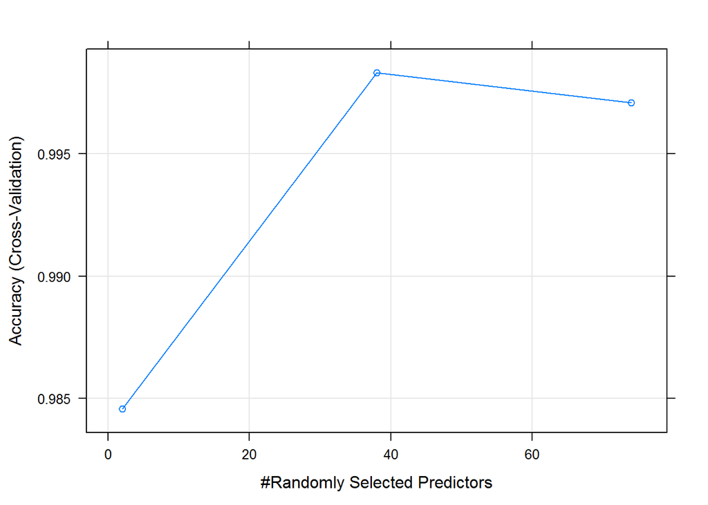

```r
plot(modelRF)
```

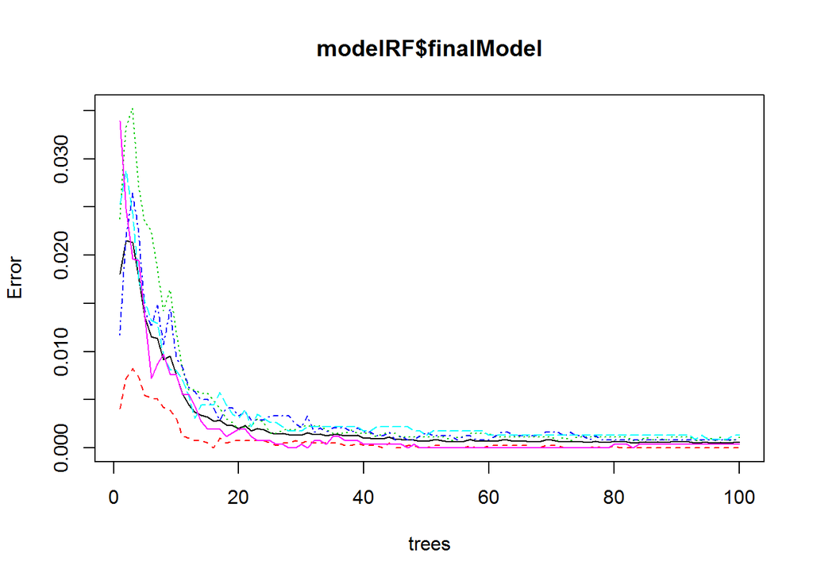

```r
#getTree(modelRF$finalModel, k = 74)
plot(modelRF$finalModel)
```

```r
predRF <- predict(modelRF, testing)
confusionMatrix(predRF, testing$classe)
```

```
## Confusion Matrix and Statistics
##
##           Reference
## Prediction    A    B    C    D    E
##          A 1674    0    0    0    0
##          B    0 1138    2    0    0
##          C    0    1 1022    0    0
##          D    0    0    2  963    0
##          E    0    0    0    1 1082
##
## Overall Statistics
##
##                Accuracy : 0.999
##                  95% CI : (0.9978, 0.9996)
##     No Information Rate : 0.2845
##     P-Value [Acc > NIR] : < 2.2e-16
##
##                   Kappa : 0.9987
##  Mcnemar's Test P-Value : NA
##
## Statistics by Class:
##
##                      Class: A Class: B Class: C Class: D Class: E
## Sensitivity            1.0000   0.9991   0.9961   0.9990   1.0000
## Specificity            1.0000   0.9996   0.9998   0.9996   0.9998
## Pos Pred Value         1.0000   0.9982   0.9990   0.9979   0.9991
## Neg Pred Value         1.0000   0.9998   0.9992   0.9998   1.0000
## Prevalence             0.2845   0.1935   0.1743   0.1638   0.1839
## Detection Rate         0.2845   0.1934   0.1737   0.1636   0.1839
## Detection Prevalence   0.2845   0.1937   0.1738   0.1640   0.1840
## Balanced Accuracy      1.0000   0.9994   0.9979   0.9993   0.9999
```

Accuracy of 0.99. Great Model, better than a single decision tree as expected.

## Predicting on Test Set

```r
predRF <- predict(modelRF, test)
predRF
```

```
##  [1] B A B A A E D B A A B C B A E E A B B B
## Levels: A B C D E
```

## GBM Model

For a gradient boosting machine (GBM) model, there are three main tuning parameters: - number of iterations, i.e. trees, (called n.trees in the gbm function)  
- complexity of the tree, called interaction.depth  
- learning rate: how quickly the algorithm adapts, called shrinkage  
- the minimum number of training set samples in a node to commence splitting (n.minobsinnode)

```r
fitControl <- trainControl(## 10-fold CV
                           method = "repeatedcv",
                           number = 3,
                           classProbs = TRUE,
                           ## repeated ten times
                           repeats = 3)

#gbmGrid <-  expand.grid(interaction.depth = c(1, 5, 9),
#                        n.trees = (1:30)*50,
#                        shrinkage = 0.1,
#                        n.minobsinnode = 20)
set.seed(825)
gbmFit1 <- train(classe ~ ., data = training,
                 method = "gbm",
                 trControl = fitControl,
                 ## This last option is actually one
                 ## for gbm() that passes through
                 verbose = FALSE)
                 #tuneGrid = gbmGrid,
                 ## Specify which metric to optimize
                 #metric = "ROC"
gbmFit1
```

```
## Stochastic Gradient Boosting
##
## 13737 samples
##    56 predictor
##     5 classes: 'A', 'B', 'C', 'D', 'E'
##
## No pre-processing
## Resampling: Cross-Validated (3 fold, repeated 3 times)
## Summary of sample sizes: 9157, 9158, 9159, 9157, 9160, 9157, ...
## Resampling results across tuning parameters:
##
##   interaction.depth  n.trees  Accuracy   Kappa
##   1                   50      0.8379322  0.7943016
##   1                  100      0.8992265  0.8723973
##   1                  150      0.9270831  0.9076365
##   2                   50      0.9561526  0.9444920
##   2                  100      0.9854408  0.9815835
##   2                  150      0.9917740  0.9895956
##   3                   50      0.9816313  0.9767612
##   3                  100      0.9933028  0.9915289
##   3                  150      0.9957536  0.9946290
##
## Tuning parameter 'shrinkage' was held constant at a value of 0.1
##
## Tuning parameter 'n.minobsinnode' was held constant at a value of 10
## Accuracy was used to select the optimal model using  the largest value.
## The final values used for the model were n.trees = 150,
##  interaction.depth = 3, shrinkage = 0.1 and n.minobsinnode = 10.
```

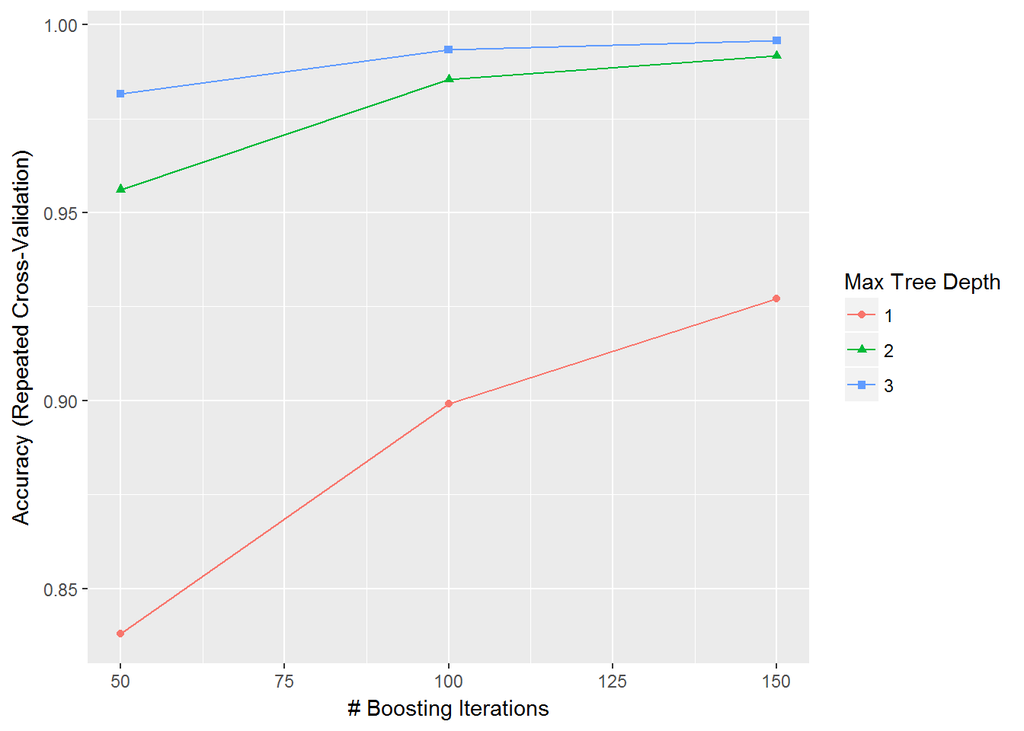

```r
# plot(gbmFit1)

# plot(gbmFit1, metric = "Kappa", plotType = "level",
#     scales = list(x = list(rot = 90)))
ggplot(gbmFit1)
```

```r
# Choosing the Final Model
whichTwoPct <- tolerance(gbmFit1$results, metric = "Accuracy",
                         tol = 2, maximize = TRUE)
cat("best model within 2 pct of best:\n")
```

```
## best model within 2 pct of best:
```

```r
gbmFit1$results[whichTwoPct,1:6]
```

```
##   shrinkage interaction.depth n.minobsinnode n.trees  Accuracy     Kappa
## 7       0.1                 3             10      50 0.9816313 0.9767612
```

The tolerance function could be used to find a less complex model based on the percent difference.  
The package assumes that increasing the number of iterations adds complexity at a faster rate than increasing the tree depth, so models are ordered on the number of iterations then ordered with depth.

## Test the Model

```r
gbmPred <- predict(gbmFit1, testing)
confusionMatrix(gbmPred, testing$classe)
```

```
## Confusion Matrix and Statistics
##
##           Reference
## Prediction    A    B    C    D    E
##          A 1667    1    0    0    0
##          B    7 1135    3    0    0
##          C    0    2 1011    1    0
##          D    0    1   12  962    0
##          E    0    0    0    1 1082
##
## Overall Statistics
##
##                Accuracy : 0.9952
##                  95% CI : (0.9931, 0.9968)
##     No Information Rate : 0.2845
##     P-Value [Acc > NIR] : < 2.2e-16
##
##                   Kappa : 0.994
##  Mcnemar's Test P-Value : NA
##
## Statistics by Class:
##
##                      Class: A Class: B Class: C Class: D Class: E
## Sensitivity            0.9958   0.9965   0.9854   0.9979   1.0000
## Specificity            0.9998   0.9979   0.9994   0.9974   0.9998
## Pos Pred Value         0.9994   0.9913   0.9970   0.9867   0.9991
## Neg Pred Value         0.9983   0.9992   0.9969   0.9996   1.0000
## Prevalence             0.2845   0.1935   0.1743   0.1638   0.1839
## Detection Rate         0.2833   0.1929   0.1718   0.1635   0.1839
## Detection Prevalence   0.2834   0.1946   0.1723   0.1657   0.1840
## Balanced Accuracy      0.9978   0.9972   0.9924   0.9976   0.9999
```

## Predict Results on the test set

```r
gbmTe <- predict(gbmFit1, test)
gbmTe
```

```
##  [1] B A B A A E D B A A B C B A E E A B B B
## Levels: A B C D E
```

```r
# Writing file
submit_gbm <- data.frame(X = test$X, y = gbmTe)
write.csv(submit_gbm, file = "submit.csv", row.names = FALSE)
```